# HW15_MQari

Mubashira Qari

2024-04-29

### Question 1:

Find the equation of the regression line for the given points. Round any final values to the nearest hundredth, if necessary. ( 5.6, 8.8 ), ( 6.3, 12.4 ), ( 7, 14.8 ), ( 7.7, 18.2 ), ( 8.4, 20.8 )

### Solution:

### Apply the Linear Model:

```r
x <- c(5.6, 6.3, 7, 7.7, 8.4)
y <- c(8.8, 12.4, 14.8, 18.2, 20.8)
df <- data.frame(x, y)
df
```

```
##     x    y
## 1 5.6  8.8
## 2 6.3 12.4
## 3 7.0 14.8
## 4 7.7 18.2
## 5 8.4 20.8
```

```r
reg_model <- lm(y~x, data=df)

reg_model
```

```
##
## Call:
## lm(formula = y ~ x, data = df)
##
## Coefficients:
## (Intercept)            x
##     -14.800        4.257
```

### Visualize the Plot:

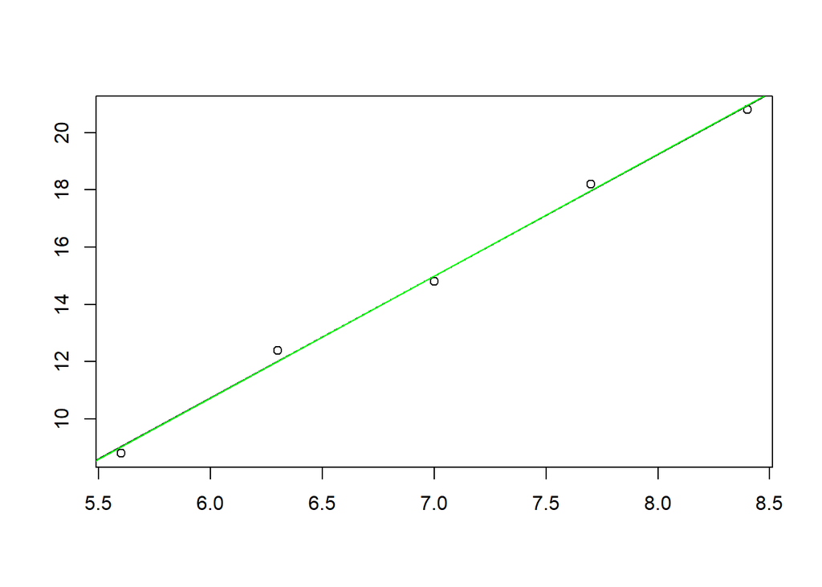

```r
plot(x,y, xlab="", ylab="")
abline(reg_model)
lines(c(5,9), -14.8+4.257*c(5,9), col="green")
```

### Question 2:

Find all local maxima, local minima, and saddle points for the function given below. Write your answer(s) in the form ( x, y, z ). Separate multiple points with a comma.

$$f(x, y) = 24x - 6xy^2 -8y^3$$

### Solution:

To all local maxima, local minima, and saddle points for the function, we have to first calculate the Determinant:

Finding Partial Derivatives:

$$f(x, y) = 24x - 6xy^2 -8y^3$$

$$fx = \frac{\partial f}{\partial x}=24 -
6y^2$$

Finding Critical Points:

$$fx = \frac{\partial f}{\partial x}=24 -
6y^2 = 0$$

$$6y^2 = 24$$

$$y^2 = 4$$

$$y = \pm 2$$

Substituting the values to solve for x

$$\frac{\partial f}{\partial y}=12xy -
24y^2=0$$

$$xy + 2y^2=0$$

$$y(x + 2y)=0$$

When
$$y=2; 2(x+2*2)=0$$

$$2x+8=0$$

$$x=-4$$

When
$$y=-2; -2(x+2*(-2))=0$$

$$-2x+8=0$$

$$x=4$$

There are two critical points at (−4,2) and (4,−2)

At (−4,2)

$$z=24(-4)-6(-4)2^2-8(2)^3=-64$$

and at (4,−2)

two critical points are (−4,2,−64) and (4,−2,64), but to find out if they are minima, maxima or saddle points, we need to find the determinant, D.

Finding the Determinant

$$fxx =0$$

$$fyy =-12x-48y$$

$$fxy =-12y$$

Now
$$fxxfyy-f^2xy=-(-12y)^2 =-144y^2$$

D(x,y)<0 for all (x,y), On the basis of the Second Derivative Test, any critical point is a saddle point.

### Question 3:

A grocery store sells two brands of a product, the “house” brand and a “name” brand. The manager estimates that if she sells the “house” brand for x dollars and the “name” brand for y dollars, she will be able to sell 81−21x+17y units of the “house” brand and 40+11x−23y units of the “name” brand.

Step 1. Find the revenue function R(x,y).

Step 2. What is the revenue if she sells the “house” brand for $2.30 and the “name” brand for $4.10?

### Solution:

$$R(x,y)=81x-21x^2+17xy+40y+11xy-23y^2$$

$$R(2.3,4.1)=116.62$$

### Question 4:

A company has a plant in Los Angeles and a plant in Denver. The firm is committed to produce a total of 96 units of a product each week. The total weekly cost is given by
$$C(x,y)=\frac{1}{6}x^2+
\frac{1}{6}y^2+7x+25y+700$$
where x is the number of units produced in Los Angeles and y is the number of units produced in Denver. How many units should be produced in each plant to minimize the total weekly cost?

### Solution:

Consider x+y=96, then x=96−y

$$C(x,y)= C(96-y,y) =\frac{1}{6}x^2+
\frac{1}{6}y^2+7x+25y+700$$

$$C(x,y)= C(96-y,y) =\frac{1}{6}(96-y)^2+
\frac{1}{6}y^2+7(96-y)+25y+700$$

$$C(x,y)= C(96-y,y)
=\frac{1}{3}y^2-14y+2908$$

$$=C_1(y)$$

$$=C'_1(y)=\frac{2}{3}y-14$$

To find minimal value by
$$=C'_1(y)=\frac{2}{3}y-14=0$$

$$y=21$$

$$x=96−y=75$$

The company needs to produce 75 units in LA and 21 units in Denver each week in order to meet their production commitment and minimize costs.

### Question 5:

Evaluate the double integral on the given region.

$$\iint_R(e^{8x+3y}dA;R:2\le x\le 4 and
2\le y\le 4$$

Write your answer in exact form without decimals.

### Solution:

$$\iint_R(e^{8x+3y}dydx=\int_{2}^{4}(\frac{1}{3}e^{8x+3y})|_{2}^{4}dx$$

$$\iint_R(e^{8x+3y}dydx=\int_{2}^{4}(\frac{1}{3}e^{8x+3y})|_{2}^{4}dx$$

$$=\int_{2}^{4}((\frac{1}{3}e^{8x+12})-(\frac{1}{3}e^{8x+6}))dx$$

$$=\int_{2}^{4}\frac{1}{3}e^{8x+6}(e^6-1)dx$$

$$=\frac{1}{24}e^{8x+6}(e^6-1)|_{2}^{4}$$

$$=\frac{1}{24}e^{32+6}(e^6-1)-\frac{1}{24}e^{16+6}(e^6-1)$$

$$=\frac{1}{24}(e^{6}-1)(e^{38}-e^{22})$$